# Fun Friday: Structural Breaks Part 1

2018-04-06

This is the introductory “Fun Friday” post, and unfortunately will be a rehash of some work I’ve done in the past with a colleague (Zachary Collier, Ph.D. Candidate in my program). The topic is a concept from econometrics called “Structural Breaks”, which are also referred to as change points in some contexts. This post walks through the application of structural breaks to SAT data using the `strucchange` package. This example was created three years ago, so other packages for performing this analysis probably exist, but that’s left as an exercise for any interested reader.

We used Structural Breaks to test the stability of SAT scores across subtests,ethnicities,and gender. A structural break appears when we see an unexpected break in a time-series. Our approach is closely related to algorithms described in Bai & Perron (2003) for simultaneous estimation of multiple breakpoints. The algorithm obtains global minimizers of the sum of squared residuals based on the principle of dynamic programming. Our SB model will consist of multiple submodels, where each submodel will detect a new change-point.

This first post introduces the package and how to use it. Future posts will apply these procedures to SAT data. For now, let’s show off the `strucchange` package.

# Part 1: Testing Structural Breaks

### a. Data setup

Structural breaks is designed to test unexpected shifts in time series. We need to determine if those shifts are detected by rises, declines, and/or abrupt changes in the data.

```r
Mean.rise <- c(0:100, by=.5)
```

We repeat the above step for a vector that steadily declines.

```r
Mean.decline <- c(100:0, by=.5)
```

```r
Mean.rise <- ts(Mean.rise, start=c(1915), end=c(2015), frequency=1)
plot(Mean.rise)
```

[figure not shown]

```r
Mean.decline <- ts(Mean.decline, start=c(1915), end=c(2015), frequency=1)
plot(Mean.decline)
```

[figure not shown]

[figure not shown]

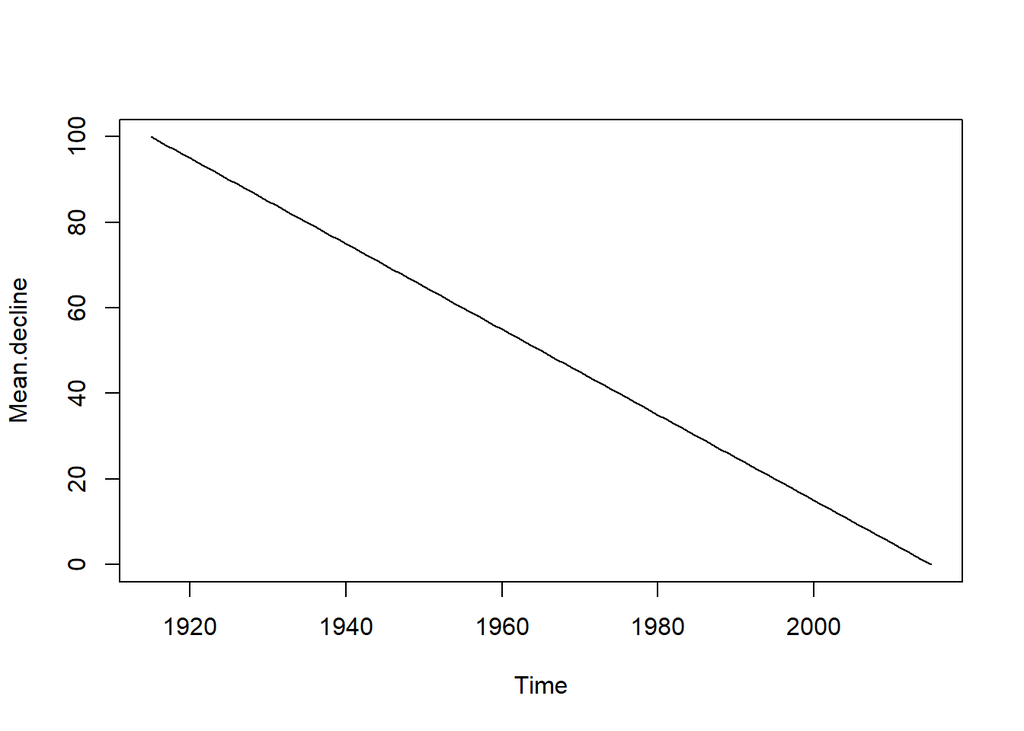

```r
Mean.decline <- ts(Mean.decline, start=c(1915), end=c(2015), frequency=1)
plot(Mean.decline)
```

### b. An Introduction to Structural Breaks Functions

Compute a series of F statistics for time-series using the `Fstats` function. Then, plot the F statistics. For every potential change point between the start and end dates, an F statistic is computed. This statistic has an asypmtotic chi-squared distribution with k degress of freedom; if the computed F statistic is significant, we reject our null hypothesis (H0: The time-series is stable). `Fstats` cannot be used to determine more than 1 breakpoint, but can indicate the location of potential breakpoints.

```r
require(strucchange)
```

```r
f.break <- Fstats(Mean.rise~1)
plot(f.break)
```

[figure not shown]

```r
f.break <- Fstats(Mean.decline~1)
plot(f.break)
```

[figure not shown]

[figure not shown]

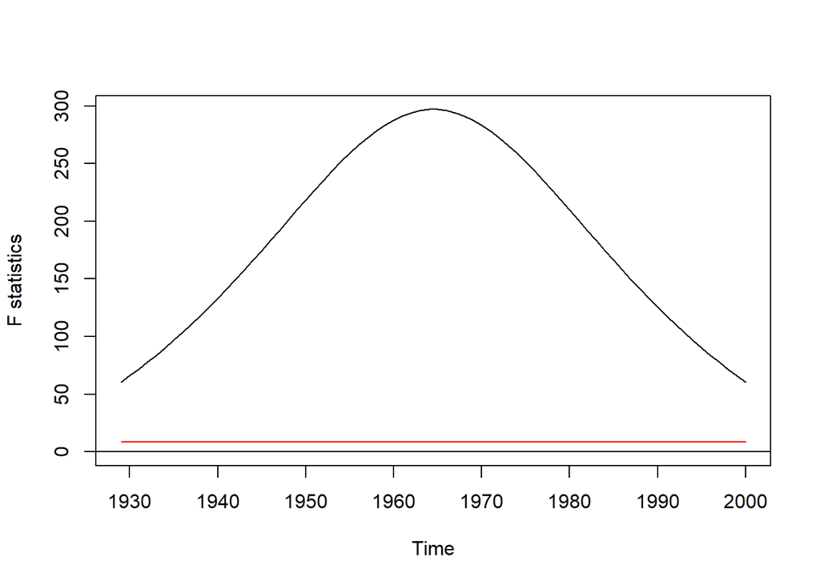

```r
f.break <- Fstats(Mean.decline~1)
plot(f.break)
```